# Superstore Sales Analysis

```
Authors           |Due Date
Grayson Gayle     | November 1, 2015
Madeline Nash     |
David Schluckebier|
```

[figure not shown]

First We created a **.Rprofile.R** document at the same level as our R script to run the needed packages. This document includes the packages required for the project. Below is the path to the .Rprofile document, and shows the loaded packages:

```r
source("../.Rprofile.R", echo = FALSE)
```

```
##
##
##
##
##
##
##
##
## Registering fonts with R
```

**DATA* The data that was later manipulated using the Tableau workspace can be accessed:

```r
superstore <-read.csv("../01 Data/Superstore.csv")
```

## **DATA VISUALIZATIONS**

#### **Customer Segment Sales per Product Category**

The first chart was generated using continuous (Sales) and categorial variables (Customer Segment and Product Category). We used this bar chart to visualize which segment was most popular regarding its sales. We can see that Corporate sales dominates and that small businesses have a small share of sales in comparison. We can also see that technology is the most popular product category and office supplies is the least popular category across all customer segments. We also wanted to determine which produt categories fell below the average sales that was calculated across all customer segments and product categories. The average, represented by a reference line was $745,994 in sales. We can see that the consumer and small business sales fall at or below this average sales calculation.

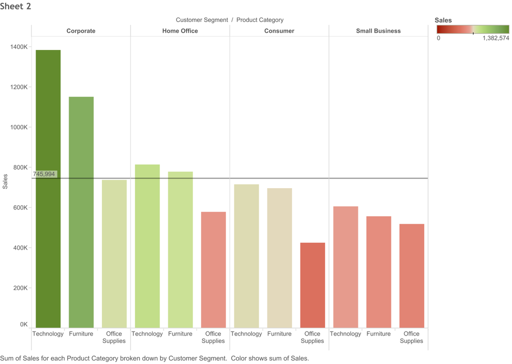

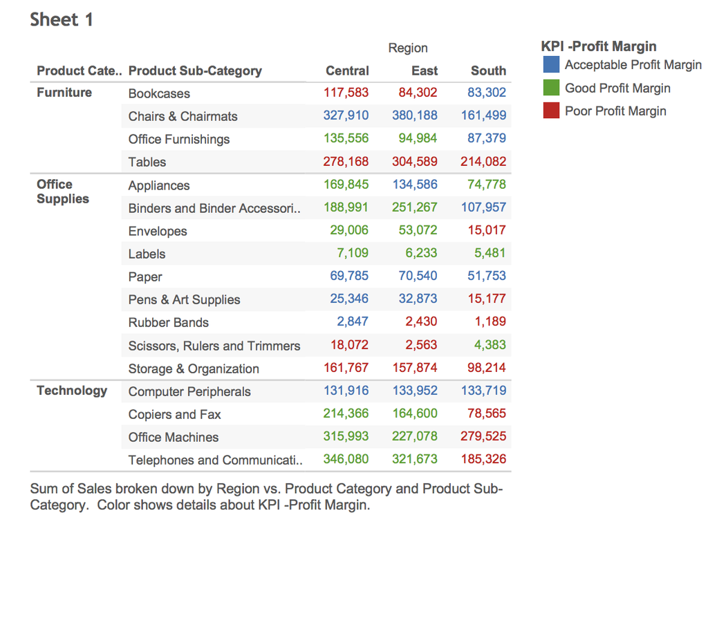

#### **Sales vs. Profit for each Region**

We created a scatter plot using two continuous variables, profit and sales, and assigned them to the colums and rows in our worksheet. We wanted to see which region had the highest correlation between profit and sales and which had the least. In the east there is an almost linear relationship between sales and profit. The south region on the other hand shows a poor correlation between profit and sales. In the west, it can be seen that there exists almost no linear relationship between sales and profit when profit is less than zero. When it is larger than zero the data points appear to show a somewhate positively linear relationship between sales and profit.

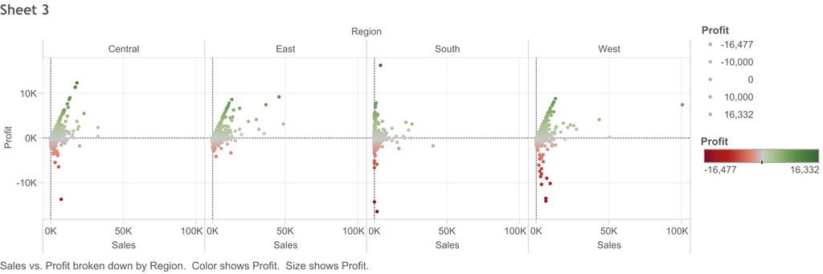